# **Analysis of Stroke Prediction in Adults🫀🩺🧠**

### Fall 2024 Data Science Project

### Sathvika Sangoju, Aman Talreja, and Aesha Kapoor

### Contributions:

- **A: Project idea** - Everyone contributed as we all spent around 20 minutes trying to find different datasets and then narrowed it down to one that we had a lot of data for and knew we could work with. (Contributors - Everyone)
- **B: Dataset Curation and Preprocessing** - Sathvika shared her screen on Google Meets, and we all went through each of the data preprocessing steps together. (Contributors - Everyone)
- **C: Data Exploration and Summary Statistics** - Sathvika shared her screen on Google Meets, and we all went through each came up with one conclusion we wanted to test, and everyone assisted reaching that conclusion. (Contributors - Everyone)
- **D: ML Algorithm Design/Development** - We talked about the different ML models together, their strengths and weaknesses, and ended up choosing to do a Logistic Regression model as well as a Decision Tree. (Contributors - Everyone)
- **E: ML Algorithm Training and Test Data Analysis** - Sathvika initiated the ML training and test data analysis and we worked through any issues together. (Contributors - Everyone)
- **F: Visualization, Result Analysis, Conclusion** - Aesha initiated the visualizations and we worked through them together. Aman initiated the conclusion and we worked through it together. We all hopped on Google Meets and analyzed the results. (Contributors - Everyone)
- **G: Final Tutorial Report Creation** - Sathvika created the final Google Colab and everyone added information from our Google Docs where we brainstormed how we wanted to structure the final reports. (Contributors - Everyone)
- **H: Additional (not listed above)** - Aman converted the Google Colab into a GitHub pages file.

# **Introduction**

**What was our motivation with this project?** Strokes are a leading cause of disability and mortality worldwide, with over 25% of adults experiencing a stroke at least once in their lifetime. This alarming statistic highlights the pervasive nature of strokes as a medical issue affecting millions globally. Our project aims to address this critical public health concern by analyzing various factors that contribute to stroke risk. By developing predictive insights, we hope to empower individuals and healthcare professionals to take preventative measures and mitigate the likelihood of strokes, ultimately improving health outcomes.

**What question(s) does our analysis answer?** The primary question we aim to answer is: “What factors (specfically, what 3 factors) significantly contribute to an individual’s risk of experiencing a stroke, and how can we predict this risk effectively?” We are interested in exploring demographic factors such as marital status and how they might influence stroke risk, as well as lifestyle-related variables, including the effects of one’s work environment. In addition, we plan to investigate critical health indicators, such as BMI, hypertension, and smoking habits, to better understand their impact on stroke occurrence. By diving deeper into these and other variables like age, physical activity, and medical history, we aim to uncover patterns and correlations that can provide actionable insights into stroke prevention.

**Why is answering those questions important?** Understanding the factors that contribute to stroke risk is essential for early identification and prevention. Answering these questions will enable individuals to make informed decisions and adopt healthier lifestyles to reduce their stroke risk. For healthcare providers, our analysis can guide personalized recommendations, improve patient care, and help allocate resources more effectively. By understanding one’s risk level for a potential stroke, individuals can take proactive measures to protect themselves, potentially avoiding life-threatening consequences.

# **Data Curation**

**Source of Data:**

- Dataset Source: Kaggle || Owner: fedesoriano (username on Kaggle)
- Link to dataset on Kaggle:https://www.kaggle.com/datasets/fedesoriano/stroke-prediction-dataset?resource=download

**What does this data mean?** The dataset we selected is highly relevant to the topic of stroke prevention and provides valuable information for predicting stroke risk. It is well-organized and contains 12 key factors across 5,110 rows of data, offering a robust foundation for our analysis. The dataset includes variables such as marital status and work environment, which may play a role in determining an individual’s likelihood of experiencing a stroke. Additionally, it captures critical health and lifestyle indicators like BMI, hypertension, smoking habits, and more. By analyzing these factors, we aim to uncover meaningful patterns that can help people take preventative measures and reduce their risk of stroke.

**Data Transformation**: In this stage, we will clean and prepare the dataset to ensure it is suitable for the exploratoy data analysis and primary analysis stages. This will envolve handling missing values by removing rows or columns containing NaN or Unknown values, depending on their significance and frequency. Additionally, categorical variables will be converted into numerical representations using one-hot encoding, allowing them to be used effectively in machine learning models. These transformations will help standardize the data and ensure consistency, making it ready for exploratory analysis and subsequent modeling steps.

```python
# Importing libraries
import pandas as pd
import numpy as np
import matplotlib.pyplot as plt
import seaborn as sns
import scipy.stats as stats
import sklearn as sk
```

```python
# Reading in .csv file
df = pd.read_csv('healthcare-dataset-stroke-data.csv')
df.head(20)
#df.shape (shape is (5110, 12))
```

|  | id | gender | age | hypertension | heart_disease | ever_married | work_type | Residence_type | avg_glucose_level | bmi | smoking_status | stroke |
| --- | --- | --- | --- | --- | --- | --- | --- | --- | --- | --- | --- | --- |
| 0 | 9046 | Male | 67.0 | 0 | 1 | Yes | Private | Urban | 228.69 | 36.6 | formerly smoked | 1 |
| 1 | 51676 | Female | 61.0 | 0 | 0 | Yes | Self-employed | Rural | 202.21 | NaN | never smoked | 1 |
| 2 | 31112 | Male | 80.0 | 0 | 1 | Yes | Private | Rural | 105.92 | 32.5 | never smoked | 1 |
| 3 | 60182 | Female | 49.0 | 0 | 0 | Yes | Private | Urban | 171.23 | 34.4 | smokes | 1 |
| 4 | 1665 | Female | 79.0 | 1 | 0 | Yes | Self-employed | Rural | 174.12 | 24.0 | never smoked | 1 |
| 5 | 56669 | Male | 81.0 | 0 | 0 | Yes | Private | Urban | 186.21 | 29.0 | formerly smoked | 1 |
| 6 | 53882 | Male | 74.0 | 1 | 1 | Yes | Private | Rural | 70.09 | 27.4 | never smoked | 1 |
| 7 | 10434 | Female | 69.0 | 0 | 0 | No | Private | Urban | 94.39 | 22.8 | never smoked | 1 |
| 8 | 27419 | Female | 59.0 | 0 | 0 | Yes | Private | Rural | 76.15 | NaN | Unknown | 1 |
| 9 | 60491 | Female | 78.0 | 0 | 0 | Yes | Private | Urban | 58.57 | 24.2 | Unknown | 1 |
| 10 | 12109 | Female | 81.0 | 1 | 0 | Yes | Private | Rural | 80.43 | 29.7 | never smoked | 1 |
| 11 | 12095 | Female | 61.0 | 0 | 1 | Yes | Govt_job | Rural | 120.46 | 36.8 | smokes | 1 |
| 12 | 12175 | Female | 54.0 | 0 | 0 | Yes | Private | Urban | 104.51 | 27.3 | smokes | 1 |
| 13 | 8213 | Male | 78.0 | 0 | 1 | Yes | Private | Urban | 219.84 | NaN | Unknown | 1 |
| 14 | 5317 | Female | 79.0 | 0 | 1 | Yes | Private | Urban | 214.09 | 28.2 | never smoked | 1 |
| 15 | 58202 | Female | 50.0 | 1 | 0 | Yes | Self-employed | Rural | 167.41 | 30.9 | never smoked | 1 |
| 16 | 56112 | Male | 64.0 | 0 | 1 | Yes | Private | Urban | 191.61 | 37.5 | smokes | 1 |
| 17 | 34120 | Male | 75.0 | 1 | 0 | Yes | Private | Urban | 221.29 | 25.8 | smokes | 1 |
| 18 | 27458 | Female | 60.0 | 0 | 0 | No | Private | Urban | 89.22 | 37.8 | never smoked | 1 |
| 19 | 25226 | Male | 57.0 | 0 | 1 | No | Govt_job | Urban | 217.08 | NaN | Unknown | 1 |

```python
# Dropping the "id" column to anonymize data. We also do not need this column for our analysis.
df = df.drop('id', axis=1)
df.head(20)
#df.shape (shape is (5110, 11))
```

|  | gender | age | hypertension | heart_disease | ever_married | work_type | Residence_type | avg_glucose_level | bmi | smoking_status | stroke |
| --- | --- | --- | --- | --- | --- | --- | --- | --- | --- | --- | --- |
| 0 | Male | 67.0 | 0 | 1 | Yes | Private | Urban | 228.69 | 36.6 | formerly smoked | 1 |
| 1 | Female | 61.0 | 0 | 0 | Yes | Self-employed | Rural | 202.21 | NaN | never smoked | 1 |
| 2 | Male | 80.0 | 0 | 1 | Yes | Private | Rural | 105.92 | 32.5 | never smoked | 1 |
| 3 | Female | 49.0 | 0 | 0 | Yes | Private | Urban | 171.23 | 34.4 | smokes | 1 |
| 4 | Female | 79.0 | 1 | 0 | Yes | Self-employed | Rural | 174.12 | 24.0 | never smoked | 1 |
| 5 | Male | 81.0 | 0 | 0 | Yes | Private | Urban | 186.21 | 29.0 | formerly smoked | 1 |
| 6 | Male | 74.0 | 1 | 1 | Yes | Private | Rural | 70.09 | 27.4 | never smoked | 1 |
| 7 | Female | 69.0 | 0 | 0 | No | Private | Urban | 94.39 | 22.8 | never smoked | 1 |
| 8 | Female | 59.0 | 0 | 0 | Yes | Private | Rural | 76.15 | NaN | Unknown | 1 |
| 9 | Female | 78.0 | 0 | 0 | Yes | Private | Urban | 58.57 | 24.2 | Unknown | 1 |
| 10 | Female | 81.0 | 1 | 0 | Yes | Private | Rural | 80.43 | 29.7 | never smoked | 1 |
| 11 | Female | 61.0 | 0 | 1 | Yes | Govt_job | Rural | 120.46 | 36.8 | smokes | 1 |
| 12 | Female | 54.0 | 0 | 0 | Yes | Private | Urban | 104.51 | 27.3 | smokes | 1 |
| 13 | Male | 78.0 | 0 | 1 | Yes | Private | Urban | 219.84 | NaN | Unknown | 1 |
| 14 | Female | 79.0 | 0 | 1 | Yes | Private | Urban | 214.09 | 28.2 | never smoked | 1 |
| 15 | Female | 50.0 | 1 | 0 | Yes | Self-employed | Rural | 167.41 | 30.9 | never smoked | 1 |
| 16 | Male | 64.0 | 0 | 1 | Yes | Private | Urban | 191.61 | 37.5 | smokes | 1 |
| 17 | Male | 75.0 | 1 | 0 | Yes | Private | Urban | 221.29 | 25.8 | smokes | 1 |
| 18 | Female | 60.0 | 0 | 0 | No | Private | Urban | 89.22 | 37.8 | never smoked | 1 |
| 19 | Male | 57.0 | 0 | 1 | No | Govt_job | Urban | 217.08 | NaN | Unknown | 1 |

```python
# Dropped the NaN values in the "bmi" column to clean the data.
df = df.dropna(subset=['bmi'])
df.head(20)
#df.shape (shape is (4909, 11))
```

|  | gender | age | hypertension | heart_disease | ever_married | work_type | Residence_type | avg_glucose_level | bmi | smoking_status | stroke |
| --- | --- | --- | --- | --- | --- | --- | --- | --- | --- | --- | --- |
| 0 | Male | 67.0 | 0 | 1 | Yes | Private | Urban | 228.69 | 36.6 | formerly smoked | 1 |
| 2 | Male | 80.0 | 0 | 1 | Yes | Private | Rural | 105.92 | 32.5 | never smoked | 1 |
| 3 | Female | 49.0 | 0 | 0 | Yes | Private | Urban | 171.23 | 34.4 | smokes | 1 |
| 4 | Female | 79.0 | 1 | 0 | Yes | Self-employed | Rural | 174.12 | 24.0 | never smoked | 1 |
| 5 | Male | 81.0 | 0 | 0 | Yes | Private | Urban | 186.21 | 29.0 | formerly smoked | 1 |
| 6 | Male | 74.0 | 1 | 1 | Yes | Private | Rural | 70.09 | 27.4 | never smoked | 1 |
| 7 | Female | 69.0 | 0 | 0 | No | Private | Urban | 94.39 | 22.8 | never smoked | 1 |
| 9 | Female | 78.0 | 0 | 0 | Yes | Private | Urban | 58.57 | 24.2 | Unknown | 1 |
| 10 | Female | 81.0 | 1 | 0 | Yes | Private | Rural | 80.43 | 29.7 | never smoked | 1 |
| 11 | Female | 61.0 | 0 | 1 | Yes | Govt_job | Rural | 120.46 | 36.8 | smokes | 1 |
| 12 | Female | 54.0 | 0 | 0 | Yes | Private | Urban | 104.51 | 27.3 | smokes | 1 |
| 14 | Female | 79.0 | 0 | 1 | Yes | Private | Urban | 214.09 | 28.2 | never smoked | 1 |
| 15 | Female | 50.0 | 1 | 0 | Yes | Self-employed | Rural | 167.41 | 30.9 | never smoked | 1 |
| 16 | Male | 64.0 | 0 | 1 | Yes | Private | Urban | 191.61 | 37.5 | smokes | 1 |
| 17 | Male | 75.0 | 1 | 0 | Yes | Private | Urban | 221.29 | 25.8 | smokes | 1 |
| 18 | Female | 60.0 | 0 | 0 | No | Private | Urban | 89.22 | 37.8 | never smoked | 1 |
| 20 | Female | 71.0 | 0 | 0 | Yes | Govt_job | Rural | 193.94 | 22.4 | smokes | 1 |
| 21 | Female | 52.0 | 1 | 0 | Yes | Self-employed | Urban | 233.29 | 48.9 | never smoked | 1 |
| 22 | Female | 79.0 | 0 | 0 | Yes | Self-employed | Urban | 228.70 | 26.6 | never smoked | 1 |
| 23 | Male | 82.0 | 0 | 1 | Yes | Private | Rural | 208.30 | 32.5 | Unknown | 1 |

```python
# Dropped the "Unknown" values in the "smoking_status" column to clean the data.
df = df[df['smoking_status'] != 'Unknown']
df.head(20)
#df.shape (shape is (3426, 11))
```

|  | gender | age | hypertension | heart_disease | ever_married | work_type | Residence_type | avg_glucose_level | bmi | smoking_status | stroke |
| --- | --- | --- | --- | --- | --- | --- | --- | --- | --- | --- | --- |
| 0 | Male | 67.0 | 0 | 1 | Yes | Private | Urban | 228.69 | 36.6 | formerly smoked | 1 |
| 2 | Male | 80.0 | 0 | 1 | Yes | Private | Rural | 105.92 | 32.5 | never smoked | 1 |
| 3 | Female | 49.0 | 0 | 0 | Yes | Private | Urban | 171.23 | 34.4 | smokes | 1 |
| 4 | Female | 79.0 | 1 | 0 | Yes | Self-employed | Rural | 174.12 | 24.0 | never smoked | 1 |
| 5 | Male | 81.0 | 0 | 0 | Yes | Private | Urban | 186.21 | 29.0 | formerly smoked | 1 |
| 6 | Male | 74.0 | 1 | 1 | Yes | Private | Rural | 70.09 | 27.4 | never smoked | 1 |
| 7 | Female | 69.0 | 0 | 0 | No | Private | Urban | 94.39 | 22.8 | never smoked | 1 |
| 10 | Female | 81.0 | 1 | 0 | Yes | Private | Rural | 80.43 | 29.7 | never smoked | 1 |
| 11 | Female | 61.0 | 0 | 1 | Yes | Govt_job | Rural | 120.46 | 36.8 | smokes | 1 |
| 12 | Female | 54.0 | 0 | 0 | Yes | Private | Urban | 104.51 | 27.3 | smokes | 1 |
| 14 | Female | 79.0 | 0 | 1 | Yes | Private | Urban | 214.09 | 28.2 | never smoked | 1 |
| 15 | Female | 50.0 | 1 | 0 | Yes | Self-employed | Rural | 167.41 | 30.9 | never smoked | 1 |
| 16 | Male | 64.0 | 0 | 1 | Yes | Private | Urban | 191.61 | 37.5 | smokes | 1 |
| 17 | Male | 75.0 | 1 | 0 | Yes | Private | Urban | 221.29 | 25.8 | smokes | 1 |
| 18 | Female | 60.0 | 0 | 0 | No | Private | Urban | 89.22 | 37.8 | never smoked | 1 |
| 20 | Female | 71.0 | 0 | 0 | Yes | Govt_job | Rural | 193.94 | 22.4 | smokes | 1 |
| 21 | Female | 52.0 | 1 | 0 | Yes | Self-employed | Urban | 233.29 | 48.9 | never smoked | 1 |
| 22 | Female | 79.0 | 0 | 0 | Yes | Self-employed | Urban | 228.70 | 26.6 | never smoked | 1 |
| 24 | Male | 71.0 | 0 | 0 | Yes | Private | Urban | 102.87 | 27.2 | formerly smoked | 1 |
| 25 | Male | 80.0 | 0 | 0 | Yes | Self-employed | Rural | 104.12 | 23.5 | never smoked | 1 |

```python
# One hot encoded all cateogircal vaeribale columns to make it easier to analyze our data.
df = pd.get_dummies(df, columns=['gender', 'ever_married', 'work_type', 'Residence_type', 'smoking_status'])
df = df.astype(int)
df.head(20)
#df.shape (shape is (3426, 21))
```

|  | age | hypertension | heart_disease | avg_glucose_level | bmi | stroke | gender_Female | gender_Male | gender_Other | ever_married_No | ... | work_type_Govt_job | work_type_Never_worked | work_type_Private | work_type_Self-employed | work_type_children | Residence_type_Rural | Residence_type_Urban | smoking_status_formerly smoked | smoking_status_never smoked | smoking_status_smokes |
| --- | --- | --- | --- | --- | --- | --- | --- | --- | --- | --- | --- | --- | --- | --- | --- | --- | --- | --- | --- | --- | --- |
| 0 | 67 | 0 | 1 | 228 | 36 | 1 | 0 | 1 | 0 | 0 | ... | 0 | 0 | 1 | 0 | 0 | 0 | 1 | 1 | 0 | 0 |
| 2 | 80 | 0 | 1 | 105 | 32 | 1 | 0 | 1 | 0 | 0 | ... | 0 | 0 | 1 | 0 | 0 | 1 | 0 | 0 | 1 | 0 |
| 3 | 49 | 0 | 0 | 171 | 34 | 1 | 1 | 0 | 0 | 0 | ... | 0 | 0 | 1 | 0 | 0 | 0 | 1 | 0 | 0 | 1 |
| 4 | 79 | 1 | 0 | 174 | 24 | 1 | 1 | 0 | 0 | 0 | ... | 0 | 0 | 0 | 1 | 0 | 1 | 0 | 0 | 1 | 0 |
| 5 | 81 | 0 | 0 | 186 | 29 | 1 | 0 | 1 | 0 | 0 | ... | 0 | 0 | 1 | 0 | 0 | 0 | 1 | 1 | 0 | 0 |
| 6 | 74 | 1 | 1 | 70 | 27 | 1 | 0 | 1 | 0 | 0 | ... | 0 | 0 | 1 | 0 | 0 | 1 | 0 | 0 | 1 | 0 |
| 7 | 69 | 0 | 0 | 94 | 22 | 1 | 1 | 0 | 0 | 1 | ... | 0 | 0 | 1 | 0 | 0 | 0 | 1 | 0 | 1 | 0 |
| 10 | 81 | 1 | 0 | 80 | 29 | 1 | 1 | 0 | 0 | 0 | ... | 0 | 0 | 1 | 0 | 0 | 1 | 0 | 0 | 1 | 0 |
| 11 | 61 | 0 | 1 | 120 | 36 | 1 | 1 | 0 | 0 | 0 | ... | 1 | 0 | 0 | 0 | 0 | 1 | 0 | 0 | 0 | 1 |
| 12 | 54 | 0 | 0 | 104 | 27 | 1 | 1 | 0 | 0 | 0 | ... | 0 | 0 | 1 | 0 | 0 | 0 | 1 | 0 | 0 | 1 |
| 14 | 79 | 0 | 1 | 214 | 28 | 1 | 1 | 0 | 0 | 0 | ... | 0 | 0 | 1 | 0 | 0 | 0 | 1 | 0 | 1 | 0 |
| 15 | 50 | 1 | 0 | 167 | 30 | 1 | 1 | 0 | 0 | 0 | ... | 0 | 0 | 0 | 1 | 0 | 1 | 0 | 0 | 1 | 0 |
| 16 | 64 | 0 | 1 | 191 | 37 | 1 | 0 | 1 | 0 | 0 | ... | 0 | 0 | 1 | 0 | 0 | 0 | 1 | 0 | 0 | 1 |
| 17 | 75 | 1 | 0 | 221 | 25 | 1 | 0 | 1 | 0 | 0 | ... | 0 | 0 | 1 | 0 | 0 | 0 | 1 | 0 | 0 | 1 |
| 18 | 60 | 0 | 0 | 89 | 37 | 1 | 1 | 0 | 0 | 1 | ... | 0 | 0 | 1 | 0 | 0 | 0 | 1 | 0 | 1 | 0 |
| 20 | 71 | 0 | 0 | 193 | 22 | 1 | 1 | 0 | 0 | 0 | ... | 1 | 0 | 0 | 0 | 0 | 1 | 0 | 0 | 0 | 1 |
| 21 | 52 | 1 | 0 | 233 | 48 | 1 | 1 | 0 | 0 | 0 | ... | 0 | 0 | 0 | 1 | 0 | 0 | 1 | 0 | 1 | 0 |
| 22 | 79 | 0 | 0 | 228 | 26 | 1 | 1 | 0 | 0 | 0 | ... | 0 | 0 | 0 | 1 | 0 | 0 | 1 | 0 | 1 | 0 |
| 24 | 71 | 0 | 0 | 102 | 27 | 1 | 0 | 1 | 0 | 0 | ... | 0 | 0 | 1 | 0 | 0 | 0 | 1 | 1 | 0 | 0 |
| 25 | 80 | 0 | 0 | 104 | 23 | 1 | 0 | 1 | 0 | 0 | ... | 0 | 0 | 0 | 1 | 0 | 1 | 0 | 0 | 1 | 0 |

20 rows × 21 columns

# **Exploratory Data Analysis**

In this stage, we aim to thoroughly explore our dataset to uncover patterns, relationships, and potential issues that could influence our modeling process. This involves taking a closer look at the structure and distribution of the data to gain valuable insights. Throughout this section, we will draw conclusions based on the data and test whether they hold true, using visualizations and statistical summaries to validate our findings.

**CONCLUSION 1: ARE THERE OUTLIERS?**

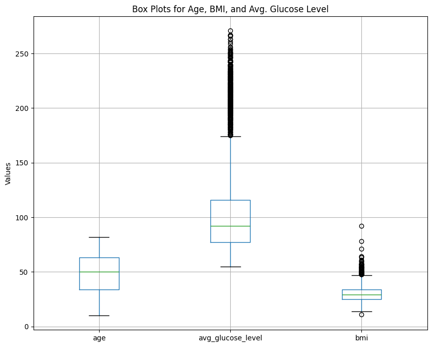

```python
# Setting the columns we want to view
columns_to_plot = ['age', 'avg_glucose_level', 'bmi']
df_to_plot = df[columns_to_plot]
# Box plot ot visaulize data for any outliers
plt.figure(figsize=(10, 8))
df_to_plot.boxplot()
plt.title('Box Plots for Age, BMI, and Avg. Glucose Level')
plt.ylabel('Values')
plt.grid(True)
plt.show()
```

**CONCLUSION 1 ANALYSIS:** Based on the visualization above, we can see that there the data contains outliers. Since there are no NaN values in these columns, we can standarduze the data instead of normalizing the data

```python
# We are stadardizing the column values for "age", "bmi", and "avg_glucose_level" to scale the data by converting the values to z-scores because they ar
from sklearn.preprocessing import StandardScaler
scaler = StandardScaler()
df[['age', 'bmi', 'avg_glucose_level']] = scaler.fit_transform(df[['age', 'bmi', 'avg_glucose_level']])
#pd.set_option('display.max_columns', None)
df.head(20)
```

|  | age | hypertension | heart_disease | avg_glucose_level | bmi | stroke | gender_Female | gender_Male | gender_Other | ever_married_No | ... | work_type_Govt_job | work_type_Never_worked | work_type_Private | work_type_Self-employed | work_type_children | Residence_type_Rural | Residence_type_Urban | smoking_status_formerly smoked | smoking_status_never smoked | smoking_status_smokes |
| --- | --- | --- | --- | --- | --- | --- | --- | --- | --- | --- | --- | --- | --- | --- | --- | --- | --- | --- | --- | --- | --- |
| 0 | 0.973768 | 0 | 1 | 2.519900 | 0.844845 | 1 | 0 | 1 | 0 | 0 | ... | 0 | 0 | 1 | 0 | 0 | 0 | 1 | 1 | 0 | 0 |
| 2 | 1.663479 | 0 | 1 | -0.059459 | 0.295850 | 1 | 0 | 1 | 0 | 0 | ... | 0 | 0 | 1 | 0 | 0 | 1 | 0 | 0 | 1 | 0 |
| 3 | 0.018784 | 0 | 0 | 1.324587 | 0.570347 | 1 | 1 | 0 | 0 | 0 | ... | 0 | 0 | 1 | 0 | 0 | 0 | 1 | 0 | 0 | 1 |
| 4 | 1.610424 | 1 | 0 | 1.387499 | -0.802140 | 1 | 1 | 0 | 0 | 0 | ... | 0 | 0 | 0 | 1 | 0 | 1 | 0 | 0 | 1 | 0 |
| 5 | 1.716533 | 0 | 0 | 1.639143 | -0.115896 | 1 | 0 | 1 | 0 | 0 | ... | 0 | 0 | 1 | 0 | 0 | 0 | 1 | 1 | 0 | 0 |
| 6 | 1.345151 | 1 | 1 | -0.793423 | -0.390394 | 1 | 0 | 1 | 0 | 0 | ... | 0 | 0 | 1 | 0 | 0 | 1 | 0 | 0 | 1 | 0 |
| 7 | 1.079877 | 0 | 0 | -0.290133 | -1.076637 | 1 | 1 | 0 | 0 | 1 | ... | 0 | 0 | 1 | 0 | 0 | 0 | 1 | 0 | 1 | 0 |
| 10 | 1.716533 | 1 | 0 | -0.583719 | -0.115896 | 1 | 1 | 0 | 0 | 0 | ... | 0 | 0 | 1 | 0 | 0 | 1 | 0 | 0 | 1 | 0 |
| 11 | 0.655440 | 0 | 1 | 0.255097 | 0.844845 | 1 | 1 | 0 | 0 | 0 | ... | 1 | 0 | 0 | 0 | 0 | 1 | 0 | 0 | 0 | 1 |
| 12 | 0.284058 | 0 | 0 | -0.080429 | -0.390394 | 1 | 1 | 0 | 0 | 0 | ... | 0 | 0 | 1 | 0 | 0 | 0 | 1 | 0 | 0 | 1 |
| 14 | 1.610424 | 0 | 1 | 2.226314 | -0.253145 | 1 | 1 | 0 | 0 | 0 | ... | 0 | 0 | 1 | 0 | 0 | 0 | 1 | 0 | 1 | 0 |
| 15 | 0.071839 | 1 | 0 | 1.240706 | 0.021352 | 1 | 1 | 0 | 0 | 0 | ... | 0 | 0 | 0 | 1 | 0 | 1 | 0 | 0 | 1 | 0 |
| 16 | 0.814604 | 0 | 1 | 1.743995 | 0.982093 | 1 | 0 | 1 | 0 | 0 | ... | 0 | 0 | 1 | 0 | 0 | 0 | 1 | 0 | 0 | 1 |
| 17 | 1.398205 | 1 | 0 | 2.373107 | -0.664891 | 1 | 0 | 1 | 0 | 0 | ... | 0 | 0 | 1 | 0 | 0 | 0 | 1 | 0 | 0 | 1 |
| 18 | 0.602386 | 0 | 0 | -0.394985 | 0.982093 | 1 | 1 | 0 | 0 | 1 | ... | 0 | 0 | 1 | 0 | 0 | 0 | 1 | 0 | 1 | 0 |
| 20 | 1.185987 | 0 | 0 | 1.785936 | -1.076637 | 1 | 1 | 0 | 0 | 0 | ... | 1 | 0 | 0 | 0 | 0 | 1 | 0 | 0 | 0 | 1 |
| 21 | 0.177948 | 1 | 0 | 2.624752 | 2.491829 | 1 | 1 | 0 | 0 | 0 | ... | 0 | 0 | 0 | 1 | 0 | 0 | 1 | 0 | 1 | 0 |
| 22 | 1.610424 | 0 | 0 | 2.519900 | -0.527642 | 1 | 1 | 0 | 0 | 0 | ... | 0 | 0 | 0 | 1 | 0 | 0 | 1 | 0 | 1 | 0 |
| 24 | 1.185987 | 0 | 0 | -0.122370 | -0.390394 | 1 | 0 | 1 | 0 | 0 | ... | 0 | 0 | 1 | 0 | 0 | 0 | 1 | 1 | 0 | 0 |
| 25 | 1.663479 | 0 | 0 | -0.080429 | -0.939389 | 1 | 0 | 1 | 0 | 0 | ... | 0 | 0 | 0 | 1 | 0 | 1 | 0 | 0 | 1 | 0 |

20 rows × 21 columns

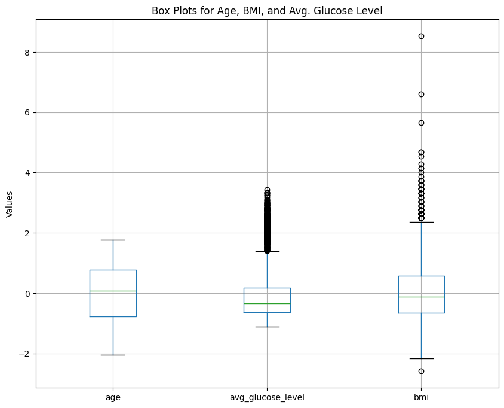

```python
# Visualizing data after standardizing it
columns_to_plot = ['age', 'avg_glucose_level', 'bmi']
df_to_plot = df[columns_to_plot]
plt.figure(figsize=(10, 8))
df_to_plot.boxplot()
plt.title('Box Plots for Age, BMI, and Avg. Glucose Level')
plt.ylabel('Values')
plt.grid(True)
plt.show()
```

**CONCLUSION 1 ANALYSIS:** Based on the visualization after standardizing the data, we can see that there are no outliers for the age. However, there are several outliers for avg_glucose_level and bmi. The outliers for avg_glucose_level are closer together, while the outliers for bmi are more spaced out.

**CONCLUSION 2: ARE BMI AND AVG_GLUCOSE_LEVEL STATISTICALLY SIGNIFICANT?**

Our hypothesis with a confidence level of 95% and an alpha value of 0.05:

- **Null Hypothesis:** The BMI and avg_glucose_level are not correlated
- **Alternative Hypothesis:** The BMI and avg_glucose_level are correlated

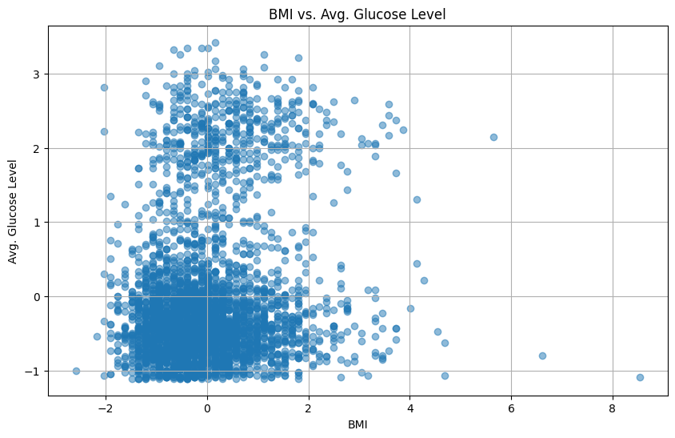

```python
# Making a scatter plot to visualize the data
plt.figure(figsize=(10, 6))
plt.scatter(df['bmi'], df['avg_glucose_level'], alpha=0.5)
plt.title('BMI vs. Avg. Glucose Level')
plt.xlabel('BMI')
plt.ylabel('Avg. Glucose Level')
plt.grid(True)
plt.show()
```

```python
# Performing Pearson Correlation Test
correlation, p_value = stats.pearsonr(df['bmi'], df['avg_glucose_level'])
print(f"Pearson Correlation Coefficient: {correlation}")
print(f"P-value: {p_value}")
```

```
Pearson Correlation Coefficient: 0.15611142307377204
P-value: 3.907066447649802e-20
```

**CONCLUSION 3: IS THE BMI STATISTICALLY SIGNIFICANT TO WHETHER SOMEONE SMOKES OR NOT?**

Our hypothesis with a confidence level of 95% and an alpha value of 0.05:

- **Null Hypothesis:** The smoking status has no effect on BMI
- **Alternative Hypothesis:** The smoking status has an effect on BMI

```python
# Split the data into two groups based on the heart disease column
yes_smoked = df[df['smoking_status_never smoked'] == 0]['bmi']
no_smoked = df[df['smoking_status_never smoked'] == 1]['bmi']

#Import ttest_ind
from scipy.stats import ttest_ind
#Implement the t-test for these two groups
t_stat, p_value = ttest_ind(yes_smoked, no_smoked, equal_var=False)

print(f'T-statistic: {t_stat}')
print(f'P-value: {p_value}')
```

```
T-statistic: 2.689885719263453
P-value: 0.007182760081744601
```

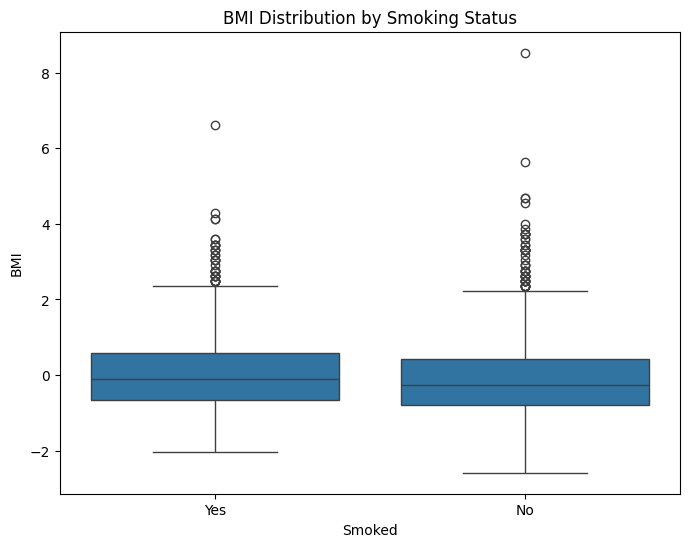

```python
#Visualizing the "yes_smoked" and the "no_smoked" with box-plots
df['smoked'] = df['smoking_status_never smoked'].apply(lambda x: 'No' if x == 1 else 'Yes')

plt.figure(figsize=(8, 6))
sns.boxplot(x='smoked', y='bmi', data=df)
plt.title('BMI Distribution by Smoking Status')
plt.xlabel('Smoked')
plt.ylabel('BMI')
plt.show()
```

**CONCLUSION 3 ANALYSIS**: Based on the results of the t-test. We can see that the p-value of 0.007 < the alpha value of 0.05. Therefore, we can reject the null hypothesis and accept the alternative hypothesis. Thus, the smoking status of a person has an effect on their BMI. Even though the visualizations of the box plots look similar, they are not the same. We can see that median BMI value of the people who smoke is slightly higher than the BMI of people who do not smoke. However,in the box plot of people who do not smoke, there are more outliers that are also more spread out comapred to people who do smoke.

# **Primary Analysis**

In this stage, we will use insights from the exploratory data analysis to select and implement a machine learning technique that aligns with the goals outlined in the introduction. Since our objective is to predict and identify factors contributing to outcomes such as stroke occurrence, we will use a supervised learning classification approach, given the categorical nature of the target variable.

We plan on implementing a logistic regression model and evaluationg the model using metrics like accuracy, precision, recall, and F1-score to ensure reliability and effectiveness in addressing the research questions.

Additionally, our goal is to identify the top three factors most strongly associated with stroke. To achieve this, we will use a decision tree to uncover thresholds and conditions that highlight the most significant contributors to stroke risk.

```python
#imports
from sklearn.model_selection import train_test_split
from sklearn.linear_model import LogisticRegression
from sklearn.metrics import accuracy_score, classification_report, confusion_matrix
from sklearn.tree import DecisionTreeClassifier
from sklearn.tree import plot_tree
import matplotlib.pyplot as plt
```

```python
# Run twice if an error presists. We do this to remove the 'smoked' column as we use it in one of our visuals above, but we don't need this column anymore.
if 'smoked' in df.columns:
    df = df.drop('smoked', axis=1)
    print(df.columns)
    print(df.dtypes)
    print(df.head())
else:
    df = df
    print()

if 'smoked' in df.columns:
    df = df.drop('smoked', axis=1)
    print(df.columns)
    print(df.dtypes)
    print(df.head())
else:
    df = df
    print()
```

```
Index(['age', 'hypertension', 'heart_disease', 'avg_glucose_level', 'bmi',
       'stroke', 'gender_Female', 'gender_Male', 'gender_Other',
       'ever_married_No', 'ever_married_Yes', 'work_type_Govt_job',
       'work_type_Never_worked', 'work_type_Private',
       'work_type_Self-employed', 'work_type_children', 'Residence_type_Rural',
       'Residence_type_Urban', 'smoking_status_formerly smoked',
       'smoking_status_never smoked', 'smoking_status_smokes'],
      dtype='object')
age                               float64
hypertension                        int64
heart_disease                       int64
avg_glucose_level                 float64
bmi                               float64
stroke                              int64
gender_Female                       int64
gender_Male                         int64
gender_Other                        int64
ever_married_No                     int64
ever_married_Yes                    int64
work_type_Govt_job                  int64
work_type_Never_worked              int64
work_type_Private                   int64
work_type_Self-employed             int64
work_type_children                  int64
Residence_type_Rural                int64
Residence_type_Urban                int64
smoking_status_formerly smoked      int64
smoking_status_never smoked         int64
smoking_status_smokes               int64
dtype: object
        age  hypertension  heart_disease  avg_glucose_level       bmi  stroke  \
0  0.973768             0              1           2.519900  0.844845       1
2  1.663479             0              1          -0.059459  0.295850       1
3  0.018784             0              0           1.324587  0.570347       1
4  1.610424             1              0           1.387499 -0.802140       1
5  1.716533             0              0           1.639143 -0.115896       1

   gender_Female  gender_Male  gender_Other  ever_married_No  ...  \
0              0            1             0                0  ...
2              0            1             0                0  ...
```

[output cut: 18 more lines]

```
   Residence_type_Urban  smoking_status_formerly smoked  \
0                     1                               1
2                     0                               0
3                     1                               0
4                     0                               0
5                     1                               1

   smoking_status_never smoked  smoking_status_smokes
0                            0                      0
2                            1                      0
3                            0                      1
4                            1                      0
5                            0                      0

[5 rows x 21 columns]
```

```python
# Unstandardize the age, bmi, and glucose_levels to get the raw value to figure out thresholds for a person to get a stroke or not in the decision tree if these end up being one of the top 3 factors.

# Retrieve the scaler's mean and scale for the columns
mean_age, mean_bmi, mean_glucose = scaler.mean_  # Mean values for the three columns
std_age, std_bmi, std_glucose = scaler.scale_    # Standard deviations for the three columns

# Reverse the standardization for 'age'
df['age'] = (df['age'] * std_age) + mean_age

# Reverse the standardization for 'bmi'
df['bmi'] = (df['bmi'] * std_bmi) + mean_bmi

# Reverse the standardization for 'avg_glucose_level'
df['avg_glucose_level'] = (df['avg_glucose_level'] * std_glucose) + mean_glucose

# Display the first few rows to verify
print(df[['age', 'bmi', 'avg_glucose_level']].head(20))
```

```
     age   bmi  avg_glucose_level
0   67.0  36.0              228.0
2   80.0  32.0              105.0
3   49.0  34.0              171.0
4   79.0  24.0              174.0
5   81.0  29.0              186.0
6   74.0  27.0               70.0
7   69.0  22.0               94.0
10  81.0  29.0               80.0
11  61.0  36.0              120.0
12  54.0  27.0              104.0
14  79.0  28.0              214.0
15  50.0  30.0              167.0
16  64.0  37.0              191.0
17  75.0  25.0              221.0
18  60.0  37.0               89.0
20  71.0  22.0              193.0
21  52.0  48.0              233.0
22  79.0  26.0              228.0
24  71.0  27.0              102.0
25  80.0  23.0              104.0
```

```python
from sklearn.linear_model import SGDClassifier
from sklearn.linear_model import LogisticRegression
from sklearn.metrics import log_loss, accuracy_score
import numpy as np
import warnings
from sklearn.exceptions import ConvergenceWarning

# Suppress convergence warnings
warnings.filterwarnings("ignore", category=ConvergenceWarning)

# Split data into training and testing sets
X = df.drop('stroke', axis=1)  # Our target variable is 'stroke'
y = df['stroke']

X_train, X_test, y_train, y_test = train_test_split(X, y, test_size=0.2, random_state=42) # Splitting data

# Initialize LogisticRegression model
model = LogisticRegression(max_iter=1, class_weight='balanced', warm_start=True, solver='lbfgs', random_state=42)

# Track metrics
train_losses = []
test_losses = []
train_accuracies = []
test_accuracies = []

# Number of iterations
n_iterations = 1000

# Training loop
for iteration in range(n_iterations):
    model.fit(X_train, y_train)

    # Predict probabilities for loss calculation
    train_probs = model.predict_proba(X_train)
    test_probs = model.predict_proba(X_test)

    # Compute log loss
    train_loss = log_loss(y_train, train_probs)
    test_loss = log_loss(y_test, test_probs)

    # Compute accuracy
    train_accuracy = model.score(X_train, y_train)
    test_accuracy = model.score(X_test, y_test)

    # Append metrics
    train_losses.append(train_loss)
    test_losses.append(test_loss)
    train_accuracies.append(train_accuracy)
    test_accuracies.append(test_accuracy)

# Final evaluation
y_pred = model.predict(X_test)
print("Final Accuracy:", accuracy_score(y_test, y_pred))
print("Classification Report:\n", classification_report(y_test, y_pred, zero_division=0))
print("Confusion Matrix:\n", confusion_matrix(y_test, y_pred))
```

```
Final Accuracy: 0.6690962099125365
Classification Report:
               precision    recall  f1-score   support

           0       0.97      0.67      0.79       642
           1       0.13      0.73      0.22        44

    accuracy                           0.67       686
   macro avg       0.55      0.70      0.50       686
weighted avg       0.92      0.67      0.75       686

Confusion Matrix:
 [[427 215]
 [ 12  32]]
```

**After completing the Logistic Regression model, we can see that our accuracy is 0.669. Moreover the precision, recall, f1-score, support, and confusion matrix are also shown which will be futher analyzed in the insights and conclusion section.**

**In the step below, we are getting the features and their associated coefficent to get the facotrs that have the highest weight. Next, we get the top 3 features indicating that these factors are provoke a stroke more than the others.**

```python
# Get feature names and corresponding coefficients
coefficients = model.coef_[0]
feature_names = X.columns

# Create a DataFrame of features and their coefficients
importance_df = pd.DataFrame({
    'Feature': feature_names,
    'Coefficient': coefficients
})

# Add a column for the absolute value of coefficients
importance_df['Absolute_Coefficient'] = np.abs(importance_df['Coefficient'])

# Sort by absolute coefficient values
importance_df = importance_df.sort_values(by='Absolute_Coefficient', ascending=False)

# Get the top 3 factors
top_3_factors = importance_df.head(3)

# Display the top 3 factors
print("All factors: ")
print(importance_df)
print()
print("Top 3 factors: ")
print(top_3_factors)
print()
print(f"The top 3 factors that lead to stroke are: {', '.join(top_3_factors['Feature'].values)}")
```

```
All factors:
                           Feature  Coefficient  Absolute_Coefficient
1                     hypertension     0.141161              0.141161
18     smoking_status_never smoked    -0.127934              0.127934
8                  ever_married_No    -0.098638              0.098638
5                    gender_Female    -0.098623              0.098623
15            Residence_type_Rural    -0.086410              0.086410
4                              bmi    -0.082547              0.082547
12               work_type_Private    -0.063987              0.063987
16            Residence_type_Urban    -0.060746              0.060746
2                    heart_disease     0.060705              0.060705
17  smoking_status_formerly smoked    -0.055389              0.055389
10              work_type_Govt_job    -0.054521              0.054521
6                      gender_Male    -0.048532              0.048532
9                 ever_married_Yes    -0.048518              0.048518
0                              age     0.041731              0.041731
19           smoking_status_smokes     0.036168              0.036168
13         work_type_Self-employed    -0.013659              0.013659
14              work_type_children    -0.013016              0.013016
3                avg_glucose_level     0.005126              0.005126
11          work_type_Never_worked    -0.001974              0.001974
7                     gender_Other     0.000000              0.000000

Top 3 factors:
                        Feature  Coefficient  Absolute_Coefficient
1                  hypertension     0.141161              0.141161
18  smoking_status_never smoked    -0.127934              0.127934
8               ever_married_No    -0.098638              0.098638

The top 3 factors that lead to stroke are: hypertension, smoking_status_never smoked, ever_married_No
```

**In the step below, we are creating a decision tree based on the top three factors that contribute to a stroke to see at what threshold one would be more at risk to get a stroke or not.**

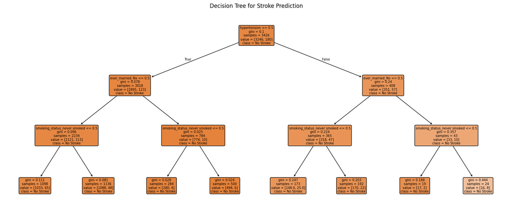

```python
# Select only relevant features
X = df[['hypertension', 'smoking_status_never smoked', 'ever_married_No']]
y = df['stroke']

# Train a decision tree classifier
tree_model = DecisionTreeClassifier(max_depth=4, random_state=42)  # Limiting depth for interpretability
tree_model.fit(X, y)

# Visualize the decision tree
plt.figure(figsize=(20, 8))
plot_tree(tree_model, feature_names=X.columns, class_names=['No Stroke', 'Stroke'], filled=True, rounded=True)
plt.title("Decision Tree for Stroke Prediction")
plt.show()
```

# **Visualization**

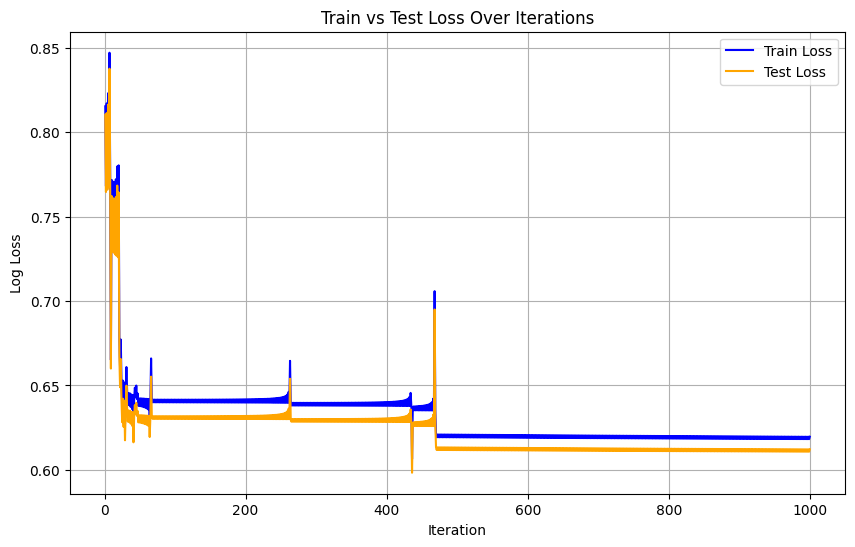

```python
import matplotlib.pyplot as plt
# Plot Train vs Test Loss
plt.figure(figsize=(10, 6))
plt.plot(range(1, n_iterations + 1), train_losses, label="Train Loss", color="blue")
plt.plot(range(1, n_iterations + 1), test_losses, label="Test Loss", color="orange")
plt.title("Train vs Test Loss Over Iterations")
plt.xlabel("Iteration")
plt.ylabel("Log Loss")
plt.legend()
plt.grid()
plt.show()
```

**The graph above shows the log loss of the train vs test data over the iterations we did. We can see from the graph that the log loss value decreases as the number of iterations increases which is ideal.This indicates that the model is learning effectively, gradually reducing the error in both the training and test sets. The decreasing log loss signifies improved predictions as the model optimizes its parameters, aligning well with the goal of minimizing loss during training.**

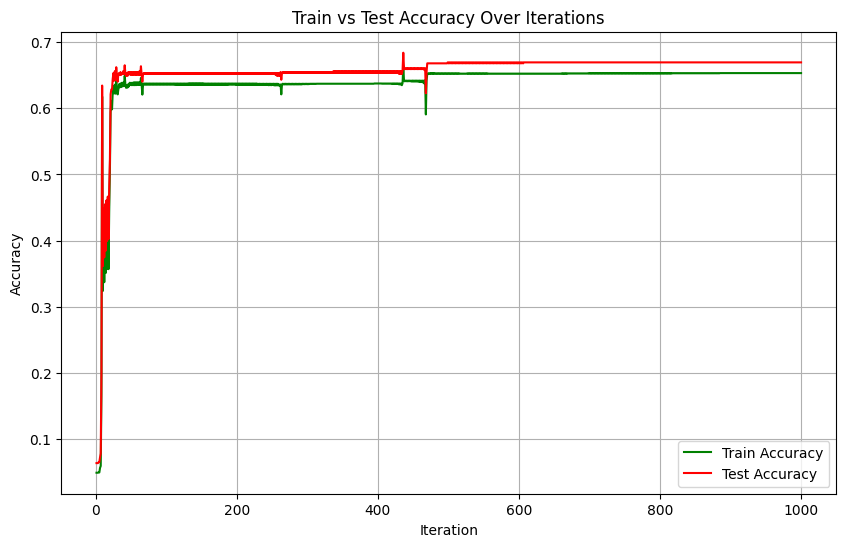

```python
# Plot Train vs Test Accuracy
plt.figure(figsize=(10, 6))
plt.plot(range(1, n_iterations + 1), train_accuracies, label="Train Accuracy", color="green")
plt.plot(range(1, n_iterations + 1), test_accuracies, label="Test Accuracy", color="red")
plt.title("Train vs Test Accuracy Over Iterations")
plt.xlabel("Iteration")
plt.ylabel("Accuracy")
plt.legend()
plt.grid()
plt.show()
```

**The graph above shows the accuracy of the train vs test data over the iterations we did. We can see from the graph that the accuracy value increases as the number of iterations increases which is ideal.This indicates that the model is effectively learning and refining its predictions as training continues. The rising accuracy signifies that the model is becoming better at generalizing patterns in the data, demonstrating its ability to optimize performance over time.**

# **Insights and Conclusions**

**Informing Uninformed Readers**: The project serves as a helpful introduction to stroke prediction for those new to the topic. It explains how different features, such as age, glucose levels, and body mass index (BMI), may contribute to stroke risk. Through clear visualizations and analysis, it guides readers in understanding the data and the significance of these features.

**Confusion Matrix Conclusion**:

Final Accuracy: 0.6690962099125365

The precision, recall, and f1-score for no-stroke (0) are 0.97, 0.67, and 0.79. For stroke (1) the values are 0.13, 0.73, and 0.22, respectively.

From these results, we can conclude that the model performs well in terms of recall for the Stroke class, correctly identifying 73% of actual stroke cases and minimizing false negatives to 12. This is an inportatn achievement in contexts where missing stroke cases could have severe consequences. However, the model struggles with precision for the Stroke class, as only 13% of predicted Stroke cases are accurate, resulting in 215 false positives. While these false positives may lead to unnecessary follow-up actions, they are less critical compared to the implications of false negatives. The relatively low overall accuracy reflects the model’s emphasis on reducing false negatives for Stroke cases, even at the cost of misclassifying some No Stroke cases. To improve the balance between precision and recall, future work could involve fine-tuning the classification threshold, exploring ensemble methods to reduce false positives while maintaining high recall, and expanding the dataset to improve generalization.

**Decision Tree Conclusion** The decision tree model, based on the current dataset, does not effectively predict strokes due to the limited amount of data available. Additionally, the depth of the tree was restricted to 4 levels to prevent overfitting, which may have further limited its ability to capture complex patterns. With more data, the model could better identify the thresholds for the top three factors that contribute to an increased risk of stroke.

These insights informed the feature selection process, ensuring that the most impactful variables were emphasized in the model.

**Class Weight for Logistic Regression Model**: When tuning the parameters of the logistic regression model, we tested both class_weight='balanced' and custom weights {0:18.0, 1:1.0}. The class_weight='balanced' parameter yielded an accuracy of 66.9%, while the custom weights produced a higher accuracy of 93.5%. However, we ultimately chose the balanced parameter because, despite the lower overall accuracy, it significantly improved the model's ability to predict stroke cases. This trade-off was crucial since the focus of this model is to better identify stroke versus non-stroke patients, prioritizing recall for the minority class over overall accuracy. This approach is more representative of real-world scenarios, where it is crucial to predict strokes accurately and minimize false negatives, as missing a stroke case can have severe consequences.

**Future Steps**: The current analysis demonstrated promising results, but future work could further enhance accuracy and precision. For example, implementing cross-validation methods would provide a more accurate evaluation of the model’s performance. Exploring ensemble methods like Random Forests could also refine predictions and address potential limitations of a single decision tree. Moreover, expanding the dataset to include more diverse samples would be invaluable for improving the model’s ability to generalize across different populations and capturing a wider range of predictive patterns. Collecting data with additional features, such as lifestyle habits, detailed medical histories, or geographic factors, could also enhance the model’s capacity to predict stroke risk. Future work could also involve fine-tuning hyperparameters and experimenting with advanced algorithms to further improve recall for stroke cases, ensuring the model remains both accurate and clinically relevant.